# Laboratiorium 2 ze statystyki

Martyna Konopacka

#### Cel

Poniższe sprawozdanie można podzielić na trzy części:

- Celem zadań 1,2 i 4 jest zastosowanie twierdzenia mówiącego, że jeśli $\hat{\theta}$ jest ENW parametru $\theta$ a $g = g(\theta)$ funkcją parametru $\theta$, to $g(\hat{\theta})$ jest ENW wielkości $g$.
- Zadanie 5 to porównanie wyników eksperymentalnego wyznaczania ENW dla rozkładów: normalnego i Laplace’a.
- W zadaniu 6 natomiast chcemy sprawdzić, jaki wpływ na szacowania ma rozmiar próby.

#### Zadanie 1

Wielkość $P(X \leq 3)$ jest funkcją parametru $p$:
$$P(p) = {5 \choose 3}p^3(1-p)^{1-3} + {5 \choose 4}p^4(1-p)^{1-4} + {5 \choose 5}p^5(1-p)^{1-5}$$
stąd estymator nawiększej wiarogodności $P$ otrzymamy wyznaczając ENW $p$ (dla tego rozkładu jest nim proporcja sukcesów) i przekazując otrzymaną wartość do funkcji $P(p)$.

Tabela 1: Średni błąd kwadratowy, wariancja i obciążenie estymatora największej wiarogodności P dla wybranych wartości parametru

| p | n | MSE | bias | var |
| --- | --- | --- | --- | --- |
| 0.1 | 50 | 0.0082477 | -0.0906803 | 0.0003642 |
| 0.3 | 50 | 0.0198273 | -0.1353981 | 0.0008587 |
| 0.5 | 50 | 0.0035856 | -0.0008535 | 0.0010366 |
| 0.9 | 50 | 0.0082477 | 0.0906803 | 0.0003642 |

1. Estymowane wartości $P(X \leq 3)$ są bliskie prawdziwym teoretycznym wartościom, a MSE, obciążenie i wariancja małe - oznacza to, że wybrany sposób estymacji jest bardzo dobry.
2. Wykonując dodatkowe eksperymenty można zauważyć, że wartości MSE, obciążenia i wariancji są symetryczne względem $p = 0.5$.

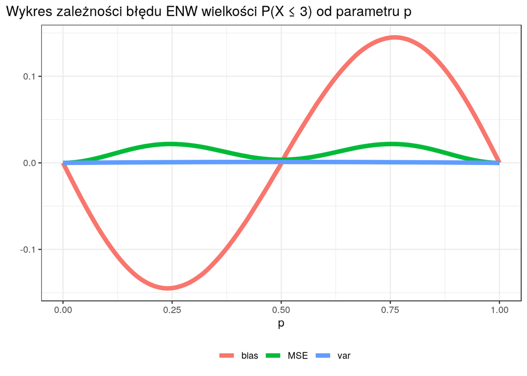

#### Zadanie 2

Estymatorem największej wiarogodności parametru $\lambda$ jest średnia arytmetyczna. W celu wyznaczenia ENW $P(X = x)$, korzystamy z tego samego sposobu co w zadaniu 1.

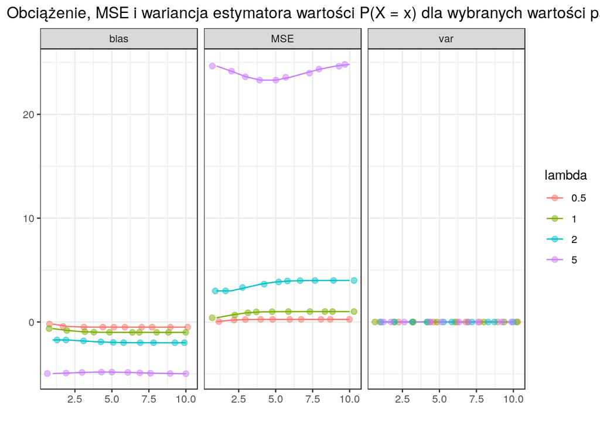

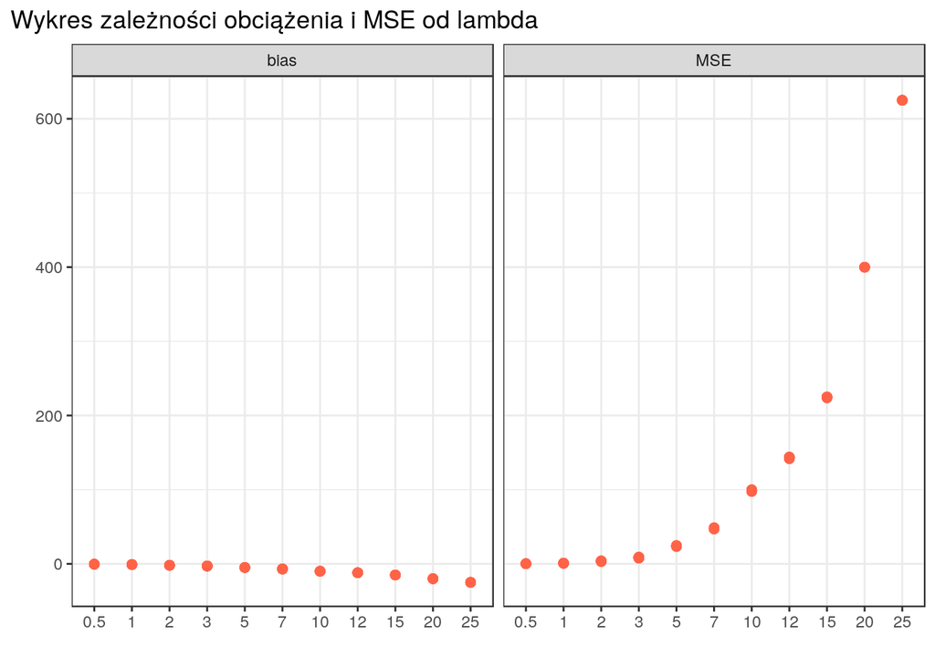